# Formula 1 Analysis

Santiago Gutierrez, Derek Rogers, Shawn Deng

2023-02-05

# 1 - Introduction

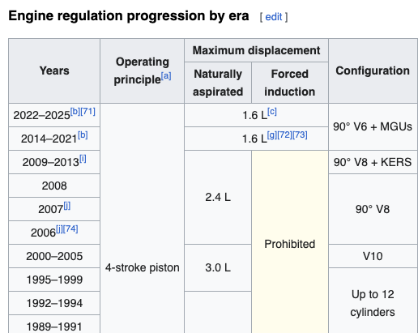

Furthermore, our analysis dives into the relationship between a driver’s starting position and the likelihood of obtaining a certain finishing result. One would assume that the better one qualifies, the higher the change of winning the race. Also, it is known that there are a few big teams/drivers who have dominated the sport over the years and continue to do so, thus providing relatively consistent results. One can easily assume that certain teams are much more likely to win a Grand Prix thus those teams are more statistically significant in determining the result of a race. Because of this, we also investigate the relationship between the results/points given the constructors (teams) and drivers.

Lastly, we create several prediction models that allow for predicting a race results. We use ONLY the parameters that one would have available just before a race: the team name, the driver name, the era (engine size) and the starting position.

# 2 - Packages

```r
knitr::opts_chunk$set(echo = TRUE)

library(dplyr)
library(ggplot2)
library(caret)
library(class)
```

# 3 - EDA

**Starting Position Vs Race Result**  
Unfortunately, due to lack of programming knowledge, we were unable to create the plot that we wanted. However, we found exactly what we needed online and thus decided to include that plot with the source tagged just below it.

From the plot, one can see that there does in-fact appear to be a relationship between a driver’s starting position. It is clear that the higher one starts on the grid, the higher the probability of winning the race. In addition these findings, we also noted that the lower one starts on the grid, the higher the probability of not finishing the race (DFN), which could make sense if one assumes that drivers towards the back are driving much less conservatively and thus more aggressive than those towards the front.

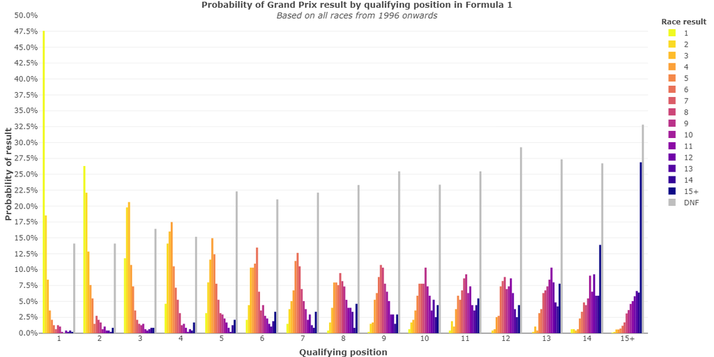

Source: MrBookman_LibraryCop”(Reddit User)  
[Click Here to Visit Source](https://www.reddit.com/r/dataisbeautiful/comments/rgt8wz/oc_formula_1_probability_of_grand_prix_result_by/)

# 4 - Modeling Data

- Driver name/id // currently only the 25 drivers with the most race results have a unique name. All other drivers have there names labeled ‘Other’.
- Constructor name/id // currently only the 25 constructors with the most reace results have a unique name. All other constructors have there names labeled ‘Other’.
- Race name/id.
- Starting position labeled ‘grid’.
- Finishing position labeled ‘positionOrder’.
- The altitude of a track.
- The era of engine size.

```r
F1DataFrame = read.csv("ModelingData/F1ModelingCustomCategoricalVariables.csv")

head(F1DataFrame)
```

```
##   X driverId constructorId circuitId raceId year                name.x resultId
## 1 1        1             1         1     18 2008 Australian Grand Prix        1
## 2 2        1             1        35    875 2012     Korean Grand Prix    21601
## 3 3        1             1        11     46 2007  Hungarian Grand Prix      589
## 4 4        1           131        22   1026 2019   Japanese Grand Prix    24528
## 5 5        1             1         7    344 2010   Canadian Grand Prix    20491
## 6 6        1             1         4      5 2009    Spanish Grand Prix     7642
##   grid positionOrder                         name.y alt     name forename
## 1    1             1 Albert Park Grand Prix Circuit  10  McLaren    Lewis
## 2    3            10   Korean International Circuit   0  McLaren    Lewis
## 3    1             1                    Hungaroring 264  McLaren    Lewis
## 4    4             3                 Suzuka Circuit  45 Mercedes    Lewis
## 5    1             1      Circuit Gilles Villeneuve  13  McLaren    Lewis
## 6   14             9 Circuit de Barcelona-Catalunya 109  McLaren    Lewis
##    surname       fullname                  era
## 1 Hamilton Lewis Hamilton        90 degrees V8
## 2 Hamilton Lewis Hamilton        90 degrees V8
## 3 Hamilton Lewis Hamilton        90 degrees V8
## 4 Hamilton Lewis Hamilton 90 degrees V6 + MGUs
## 5 Hamilton Lewis Hamilton        90 degrees V8
## 6 Hamilton Lewis Hamilton        90 degrees V8
```

**Logic to split data into training and testing sets.**

```r
modelVariables = c('positionOrder', 'grid', 'name', 'fullname', 'era')
modelDataframe = F1DataFrame[, modelVariables]

set.seed(4)

trainingIndices = sample(c(1:dim(modelDataframe)[1]), dim(modelDataframe)[1]*0.8)

trainingDataframe = modelDataframe[trainingIndices,]
testingDataframe = modelDataframe[-trainingIndices,]
```

# 5 - Model 1 (Liner Regression)

**The Model**  
mymodel<-lm(positionOrder ~ grid + name + fullname + era, data = F1DataFrame)

**Residuals Vs Fitted Plot**

- Shows evidence of a negative slope with variance that seems to increase as fitted values increase.
- This means the model is on average predicting worse results for drivers who finish with a good results.
- As the fitted values increase it seems to get a wider difference in predicted vs actual results.

**Q-Q Plot**

- Suggests a normal distribution can be assumed

**Scale-Location Plot**

- Provides more evidence for normality.
- There seems to be a patterns in starting at each discrete fitted value and traveling parallel to the Y axis with a sin function but with sharp 90 degree transitions.
- Currently we don’t have an explanation for why this is.

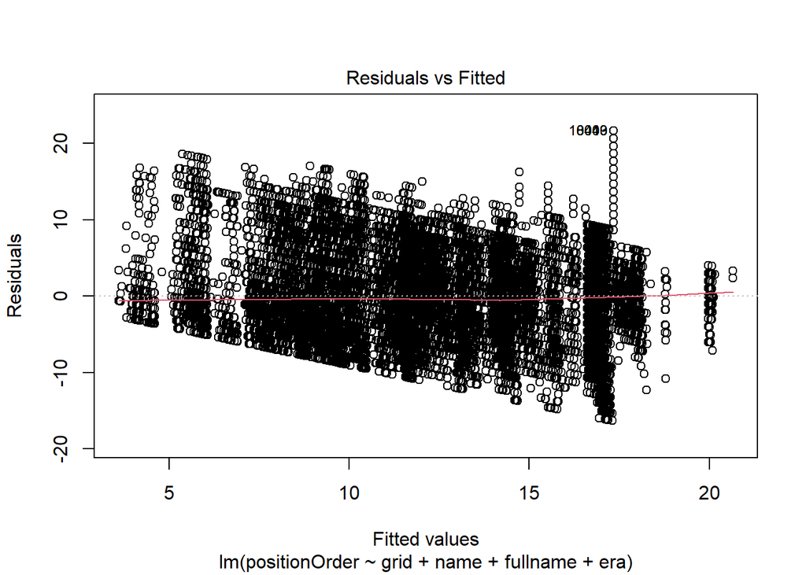

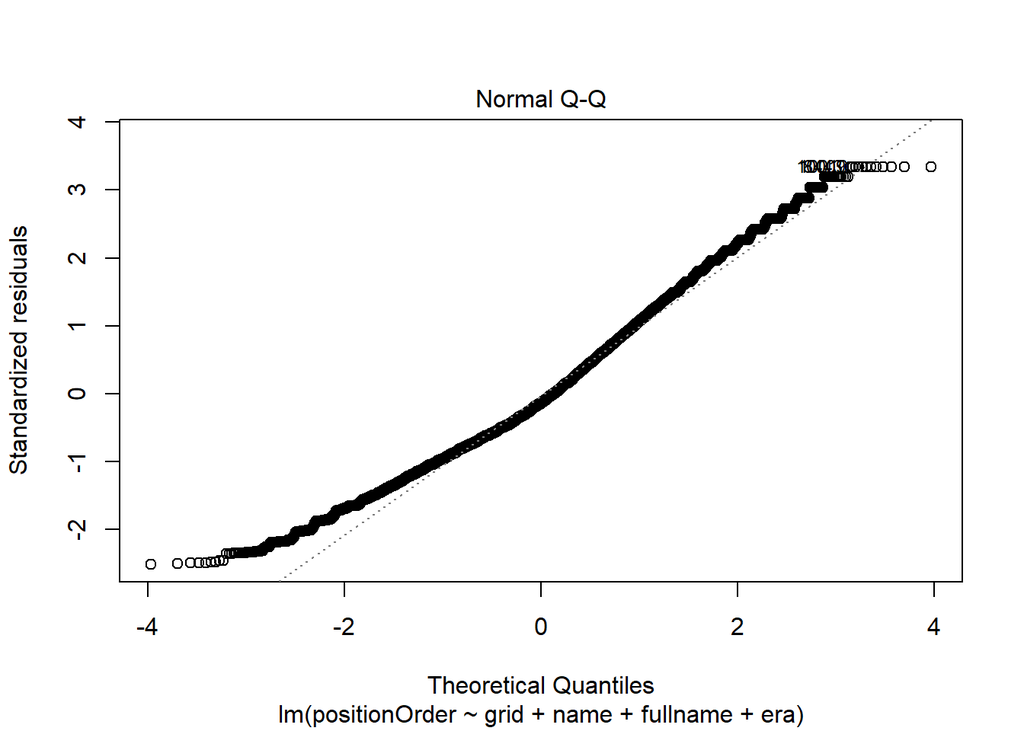

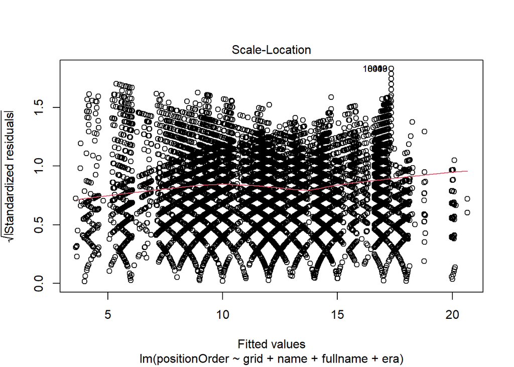

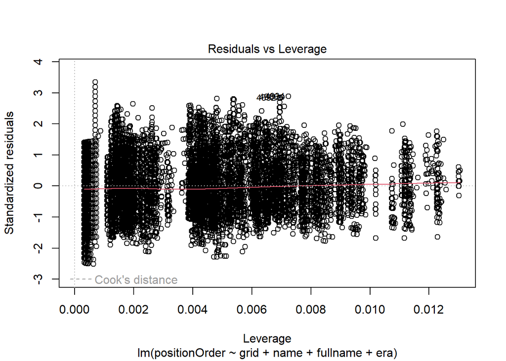

```r
mymodel<-lm(positionOrder ~ grid + name + fullname + era, data = F1DataFrame)
par(mfrow = c(1,1))
plot(mymodel)
```

**Model Summary Statistics**

```r
summary(mymodel)
```

```
##
## Call:
## lm(formula = positionOrder ~ grid + name + fullname + era, data = F1DataFrame)
##
## Residuals:
##      Min       1Q   Median       3Q      Max
## -16.3122  -4.6733  -0.9341   4.2487  21.6598
##
## Coefficients:
##                               Estimate Std. Error t value Pr(>|t|)
## (Intercept)                  15.904265   0.847114  18.775  < 2e-16 ***
## grid                         -0.028042   0.009928  -2.825 0.004742 **
## nameAlphaTauri               -2.885055   0.792023  -3.643 0.000271 ***
## nameAlpine F1 Team           -3.321502   0.888146  -3.740 0.000185 ***
## nameArrows                    1.445664   0.696238   2.076 0.037876 *
## nameBAR                      -1.136120   0.717750  -1.583 0.113469
## nameBMW Sauber               -5.609388   0.830871  -6.751 1.52e-11 ***
## nameCaterham                  2.767392   0.822187   3.366 0.000765 ***
## nameFerrari                  -4.594213   0.572806  -8.021 1.14e-15 ***
## nameForce India              -2.050777   0.668144  -3.069 0.002149 **
## nameHaas F1 Team              0.068101   0.744726   0.091 0.927141
## nameHonda                    -0.202469   0.887057  -0.228 0.819457
## nameHRT                       5.360363   0.830318   6.456 1.11e-10 ***
## nameJaguar                    0.270974   0.769901   0.352 0.724874
## nameJordan                    0.652334   0.634822   1.028 0.304162
## nameLotus F1                 -2.651931   0.804287  -3.297 0.000979 ***
## nameMarussia                  2.957332   0.829335   3.566 0.000364 ***
## nameMcLaren                  -3.608018   0.574446  -6.281 3.47e-10 ***
## nameMercedes                 -5.287063   0.662341  -7.982 1.55e-15 ***
## nameMinardi                   2.152997   0.629614   3.420 0.000629 ***
## nameOther                     3.265153   0.568550   5.743 9.50e-09 ***
## nameRed Bull                 -4.788048   0.637921  -7.506 6.48e-14 ***
## nameRenault                  -2.495175   0.621994  -4.012 6.06e-05 ***
## nameSauber                   -0.573243   0.592537  -0.967 0.333342
## nameToro Rosso               -0.559865   0.616570  -0.908 0.363877
## nameToyota                   -1.596507   0.700748  -2.278 0.022724 *
## nameWilliams                 -2.315616   0.572091  -4.048 5.20e-05 ***
## fullnameCarlos Sainz         -2.963388   0.843671  -3.512 0.000445 ***
## fullnameDaniel Ricciardo     -2.795338   0.796197  -3.511 0.000448 ***
## fullnameDavid Coulthard      -1.324745   0.788190  -1.681 0.092835 .
```

[output cut: 16 more lines]

```
## fullnameRalf Schumacher      -3.099923   0.828450  -3.742 0.000183 ***
## fullnameRomain Grosjean      -1.305760   0.919098  -1.421 0.155427
## fullnameRubens Barrichello   -3.498207   0.754031  -4.639 3.53e-06 ***
## fullnameSebastian Vettel     -5.476040   0.762718  -7.180 7.34e-13 ***
## fullnameSergio Pérez         -4.412941   0.732878  -6.021 1.77e-09 ***
## fullnameValtteri Bottas      -4.581384   0.831545  -5.509 3.66e-08 ***
## era90 degrees V8              0.187351   0.193886   0.966 0.333913
## eraUp to 12 cylinders        -1.030652   0.224903  -4.583 4.63e-06 ***
## eraV10                       -1.714270   0.247002  -6.940 4.08e-12 ***
## ---
## Signif. codes:  0 '***' 0.001 '**' 0.01 '*' 0.05 '.' 0.1 ' ' 1
##
## Residual standard error: 6.475 on 13975 degrees of freedom
## Multiple R-squared:  0.2512, Adjusted R-squared:  0.2483
## F-statistic: 86.82 on 54 and 13975 DF,  p-value: < 2.2e-16
```

**Investigation**

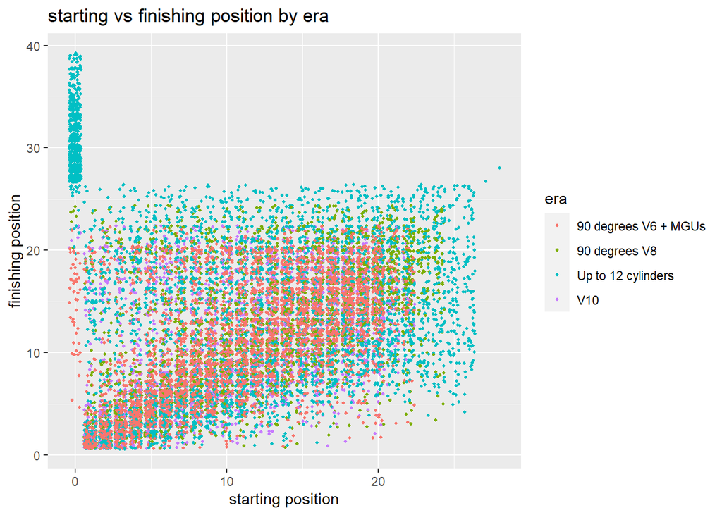

```r
mymodel<-lm(positionOrder ~ grid, data = F1DataFrame)

ggplot(data = F1DataFrame, aes(x = grid, y = positionOrder, colour = era)) +
  geom_point(position = "jitter", size = .8) +
  labs(title="starting vs finishing position by era",
     y="finishing position",
     x="starting position")
```

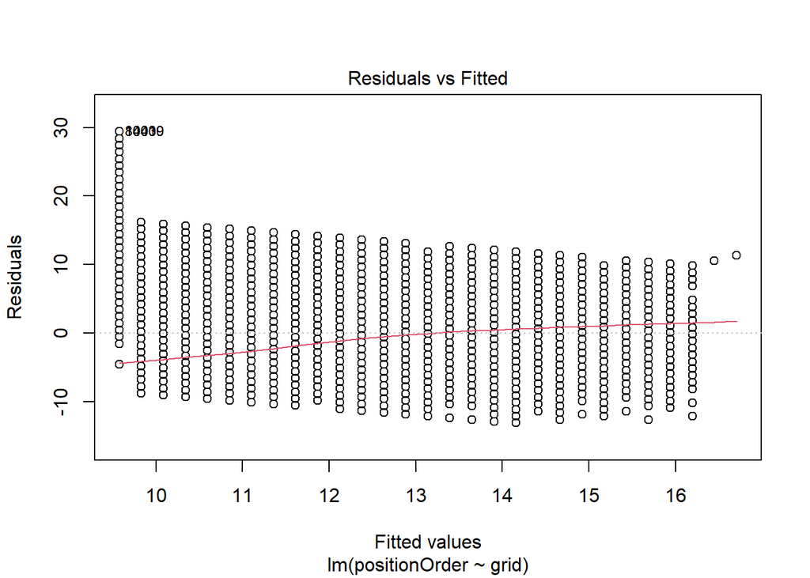

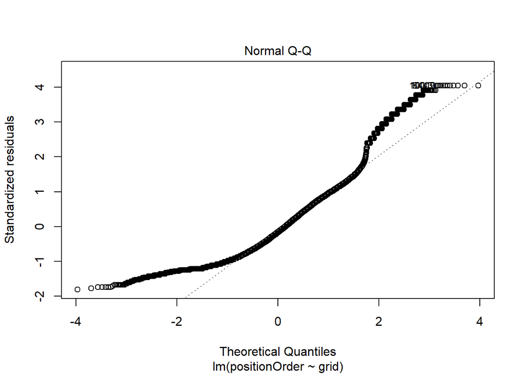

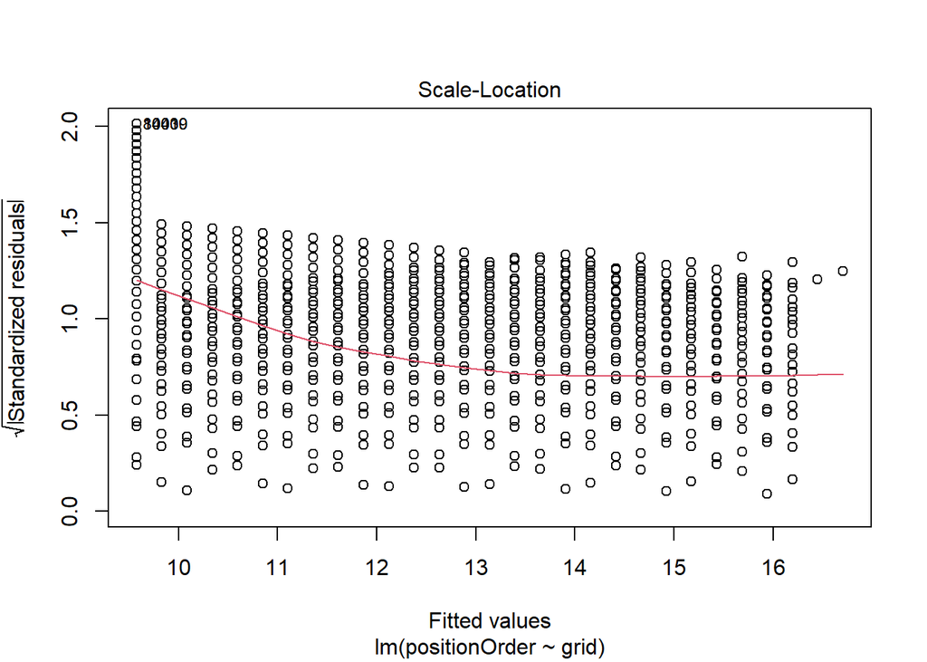

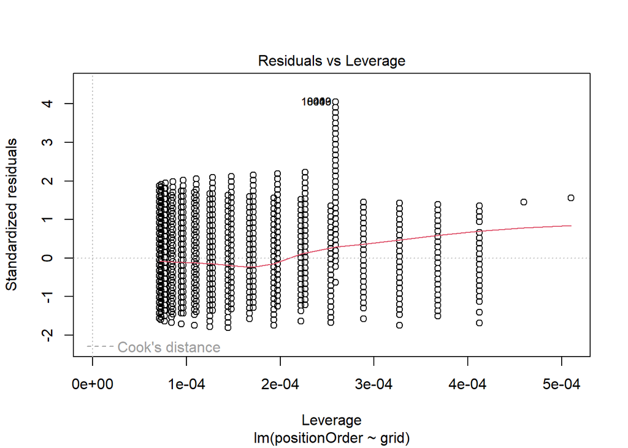

```r
mymodel<-lm(positionOrder ~ grid, data = F1DataFrame)
par(mfrow = c(1,1))
plot(mymodel)
```

# 6 - Model 2 (Liner Regression)

- The residual plots look similar to the first model.

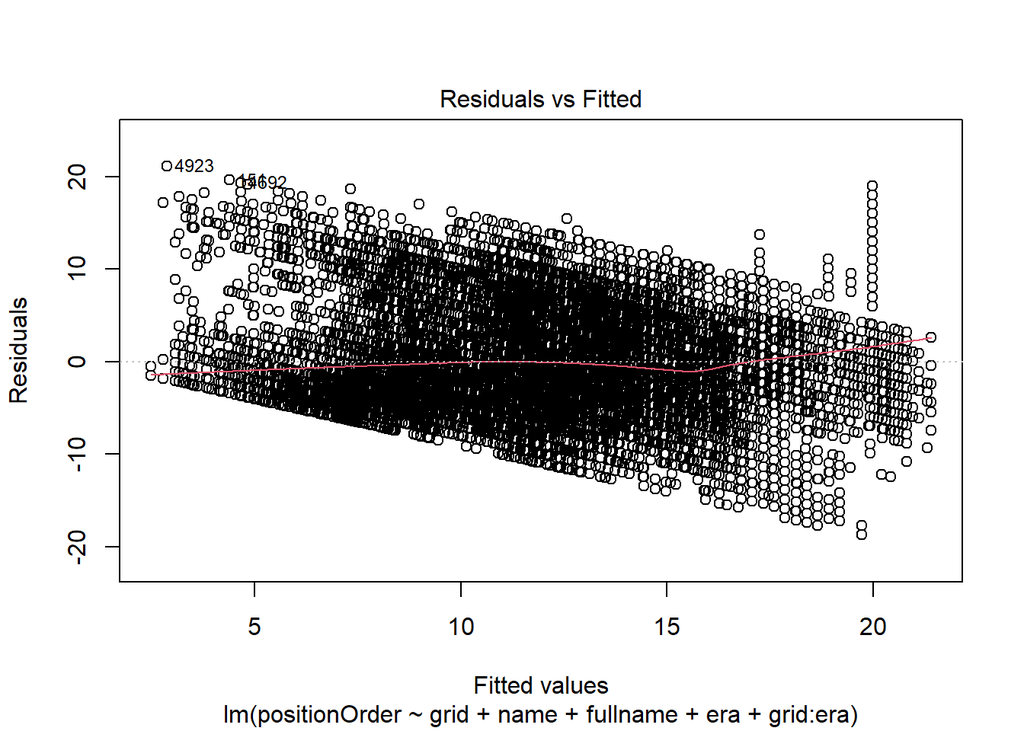

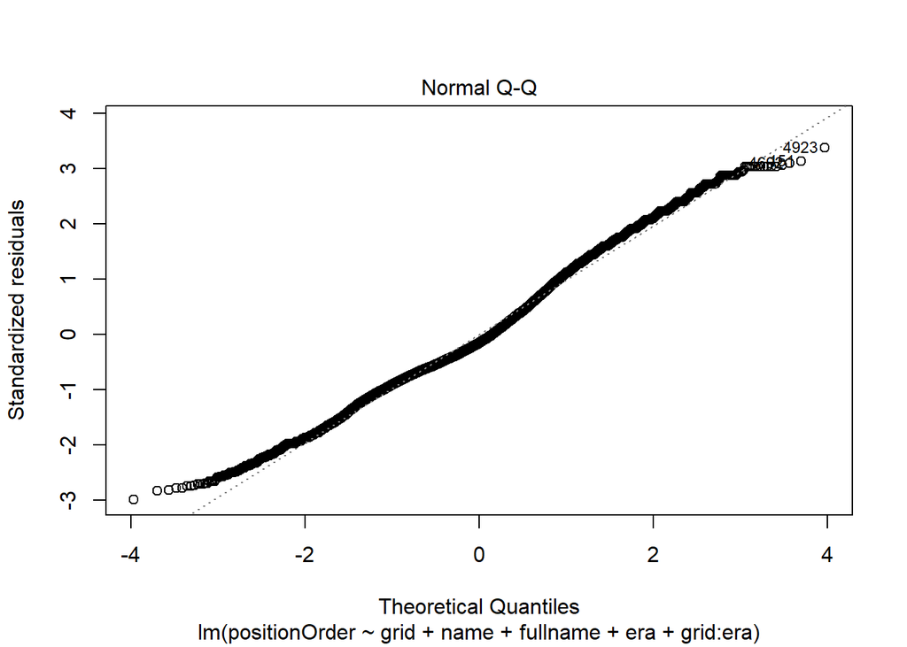

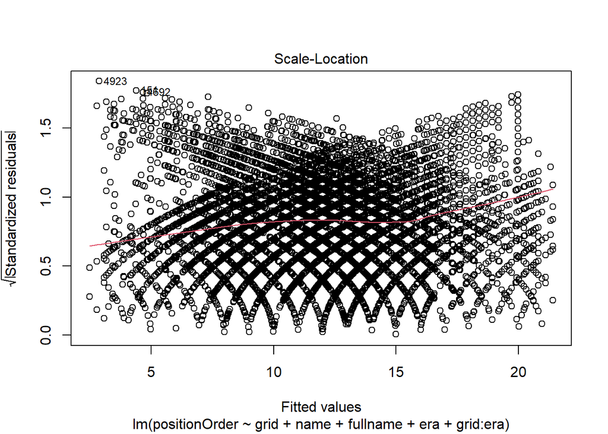

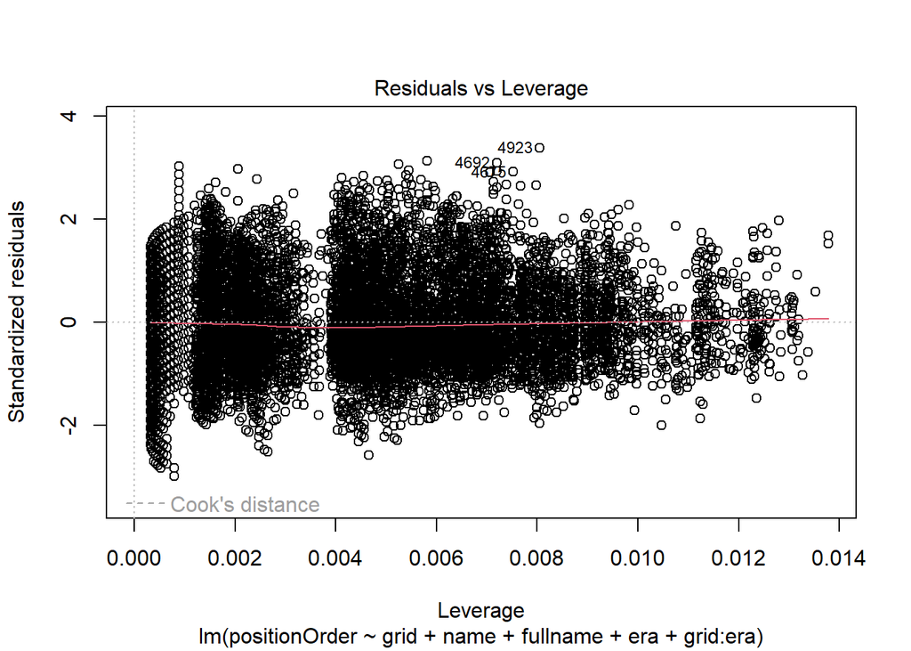

```r
mymodel<-lm(positionOrder ~ grid + name + fullname + era + grid:era, data = F1DataFrame)
par(mfrow = c(1,1))
plot(mymodel)
```

**Model 2 Summary Statistics**

```r
summary(mymodel)
```

```
##
## Call:
## lm(formula = positionOrder ~ grid + name + fullname + era + grid:era,
##     data = F1DataFrame)
##
## Residuals:
##      Min       1Q   Median       3Q      Max
## -18.7176  -4.1127  -0.9655   4.1580  21.1130
##
## Coefficients:
##                              Estimate Std. Error t value Pr(>|t|)
## (Intercept)                   9.41177    0.86433  10.889  < 2e-16 ***
## grid                          0.35243    0.02087  16.884  < 2e-16 ***
## nameAlphaTauri               -0.97200    0.77016  -1.262 0.206940
## nameAlpine F1 Team           -1.87418    0.86301  -2.172 0.029896 *
## nameArrows                    3.29077    0.68002   4.839 1.32e-06 ***
## nameBAR                       0.13513    0.69674   0.194 0.846218
## nameBMW Sauber               -3.28297    0.80768  -4.065 4.84e-05 ***
## nameCaterham                  1.72543    0.80027   2.156 0.031095 *
## nameFerrari                  -2.99281    0.55927  -5.351 8.87e-08 ***
## nameForce India              -0.86122    0.64934  -1.326 0.184760
## nameHaas F1 Team              0.31765    0.72093   0.441 0.659506
## nameHonda                     0.47512    0.86151   0.551 0.581304
## nameHRT                       3.57313    0.82482   4.332 1.49e-05 ***
## nameJaguar                    1.26720    0.75020   1.689 0.091215 .
## nameJordan                    1.62716    0.61889   2.629 0.008569 **
## nameLotus F1                 -1.72113    0.77928  -2.209 0.027217 *
## nameMarussia                  1.75713    0.80929   2.171 0.029932 *
## nameMcLaren                  -2.66087    0.55710  -4.776 1.80e-06 ***
## nameMercedes                 -2.89308    0.65481  -4.418 1.00e-05 ***
## nameMinardi                   3.84563    0.61964   6.206 5.58e-10 ***
## nameOther                     4.35723    0.55380   7.868 3.87e-15 ***
## nameRed Bull                 -2.37386    0.62358  -3.807 0.000141 ***
## nameRenault                  -1.22991    0.60376  -2.037 0.041659 *
## nameSauber                    0.14296    0.57456   0.249 0.803511
## nameToro Rosso               -0.04784    0.59830  -0.080 0.936264
## nameToyota                   -0.09829    0.68182  -0.144 0.885382
## nameWilliams                 -1.96670    0.55503  -3.543 0.000396 ***
## fullnameCarlos Sainz         -1.10493    0.81963  -1.348 0.177655
## fullnameDaniel Ricciardo     -1.31863    0.77272  -1.706 0.087943 .
```

[output cut: 20 more lines]

```
## fullnameSebastian Vettel     -3.22243    0.74352  -4.334 1.47e-05 ***
## fullnameSergio Pérez         -2.89172    0.71134  -4.065 4.83e-05 ***
## fullnameValtteri Bottas      -1.88704    0.81037  -2.329 0.019893 *
## era90 degrees V8              0.72803    0.35808   2.033 0.042056 *
## eraUp to 12 cylinders         6.42744    0.35294  18.211  < 2e-16 ***
## eraV10                        1.53760    0.42789   3.593 0.000327 ***
## grid:era90 degrees V8        -0.05580    0.02698  -2.068 0.038652 *
## grid:eraUp to 12 cylinders   -0.61723    0.02408 -25.635  < 2e-16 ***
## grid:eraV10                  -0.26577    0.03256  -8.163 3.54e-16 ***
## ---
## Signif. codes:  0 '***' 0.001 '**' 0.01 '*' 0.05 '.' 0.1 ' ' 1
##
## Residual standard error: 6.266 on 13972 degrees of freedom
## Multiple R-squared:  0.2989, Adjusted R-squared:  0.296
## F-statistic: 104.5 on 57 and 13972 DF,  p-value: < 2.2e-16
```

# 7 - Model 3 (Liner Regression)

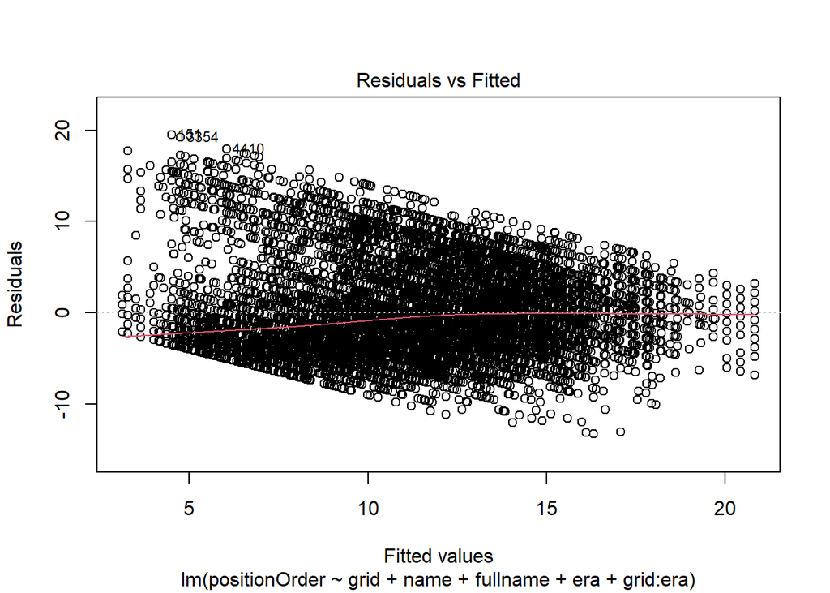

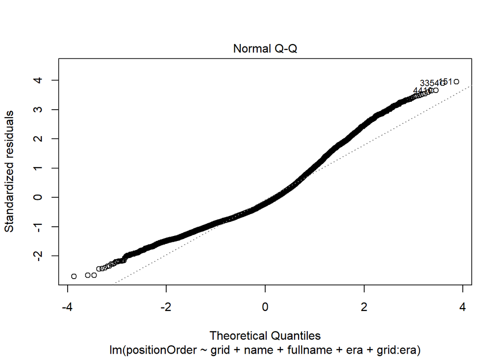

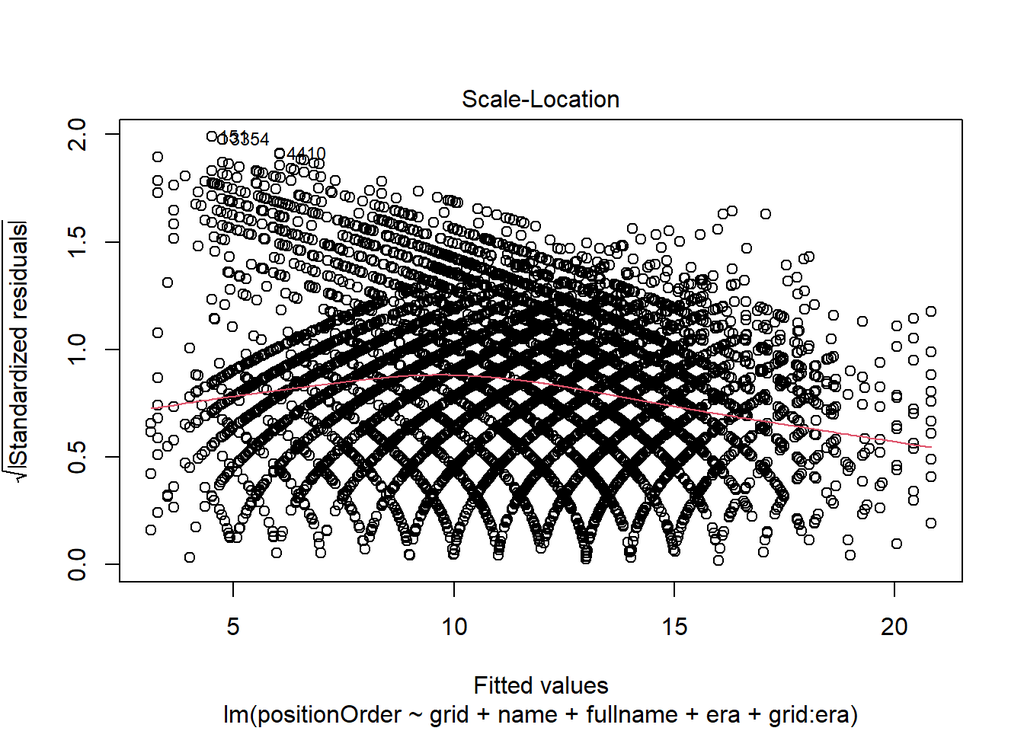

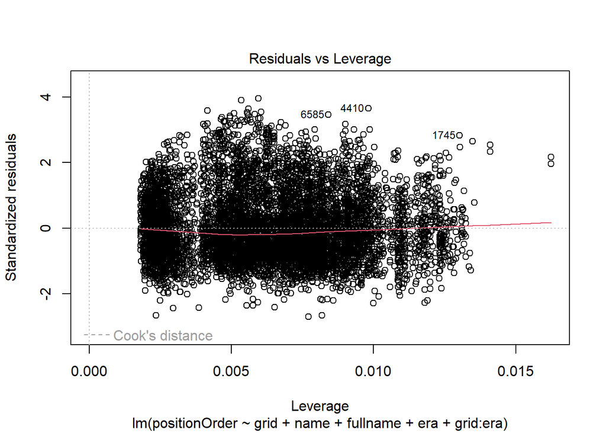

```r
F1DataFrame = F1DataFrame %>% filter(F1DataFrame$year >= "2000")
mymodel = lm(positionOrder ~ grid + name + fullname + era + grid:era, data = F1DataFrame)
simpleModel = lm(positionOrder ~ grid, data = F1DataFrame)
par(mfrow = c(1,1))
plot(mymodel)
```

**Model 3 Summary Statistics**

```r
summary(mymodel)
```

```
##
## Call:
## lm(formula = positionOrder ~ grid + name + fullname + era + grid:era,
##     data = F1DataFrame)
##
## Residuals:
##     Min      1Q  Median      3Q     Max
## -13.305  -3.527  -1.062   2.713  19.492
##
## Coefficients:
##                              Estimate Std. Error t value Pr(>|t|)
## (Intercept)                  10.18992    0.68222  14.936  < 2e-16 ***
## grid                          0.35685    0.01675  21.306  < 2e-16 ***
## nameAlphaTauri               -0.96330    0.60783  -1.585 0.113043
## nameAlpine F1 Team           -2.01214    0.68050  -2.957 0.003116 **
## nameArrows                    1.68047    0.70947   2.369 0.017875 *
## nameBAR                      -0.18805    0.58039  -0.324 0.745948
## nameBMW Sauber               -3.24381    0.63884  -5.078 3.90e-07 ***
## nameCaterham                  1.19126    0.63429   1.878 0.060402 .
## nameFerrari                  -3.45016    0.45662  -7.556 4.56e-14 ***
## nameForce India              -1.61940    0.51491  -3.145 0.001666 **
## nameHaas F1 Team              0.37112    0.56909   0.652 0.514330
## nameHonda                    -0.41850    0.69192  -0.605 0.545302
## nameHRT                       2.58153    0.65514   3.940 8.20e-05 ***
## nameJaguar                    0.77193    0.60813   1.269 0.204344
## nameJordan                    1.19768    0.58538   2.046 0.040788 *
## nameLotus F1                 -1.64706    0.61482  -2.679 0.007399 **
## nameMarussia                  1.13948    0.64156   1.776 0.075747 .
## nameMcLaren                  -1.58150    0.45005  -3.514 0.000443 ***
## nameMercedes                 -2.96328    0.52171  -5.680 1.39e-08 ***
## nameMinardi                   1.17922    0.62166   1.897 0.057874 .
## nameOther                     0.32732    0.46878   0.698 0.485051
## nameRed Bull                 -2.67785    0.49441  -5.416 6.24e-08 ***
## nameRenault                  -1.48690    0.47883  -3.105 0.001907 **
## nameSauber                   -0.28114    0.47039  -0.598 0.550072
## nameToro Rosso               -0.30402    0.47383  -0.642 0.521137
## nameToyota                   -0.71284    0.54921  -1.298 0.194339
## nameWilliams                 -0.19097    0.44755  -0.427 0.669601
## fullnameCarlos Sainz         -1.92574    0.64850  -2.970 0.002990 **
## fullnameDaniel Ricciardo     -2.15690    0.61099  -3.530 0.000417 ***
```

[output cut: 18 more lines]

```
## fullnameRomain Grosjean      -0.69624    0.70355  -0.990 0.322388
## fullnameRubens Barrichello   -1.97576    0.63877  -3.093 0.001987 **
## fullnameSebastian Vettel     -2.94648    0.58946  -4.999 5.88e-07 ***
## fullnameSergio Pérez         -2.77168    0.56127  -4.938 8.02e-07 ***
## fullnameValtteri Bottas      -3.38177    0.64398  -5.251 1.54e-07 ***
## era90 degrees V8             -0.19567    0.28781  -0.680 0.496616
## eraV10                       -0.45452    0.35751  -1.271 0.203627
## grid:era90 degrees V8         0.03029    0.02157   1.404 0.160292
## grid:eraV10                  -0.08097    0.02809  -2.882 0.003959 **
## ---
## Signif. codes:  0 '***' 0.001 '**' 0.01 '*' 0.05 '.' 0.1 ' ' 1
##
## Residual standard error: 4.939 on 9104 degrees of freedom
## Multiple R-squared:  0.367,  Adjusted R-squared:  0.3632
## F-statistic: 95.97 on 55 and 9104 DF,  p-value: < 2.2e-16
```

```r
summary(simpleModel)
```

```
##
## Call:
## lm(formula = positionOrder ~ grid, data = F1DataFrame)
##
## Residuals:
##     Min      1Q  Median      3Q     Max
## -15.289  -3.824  -1.086   3.015  18.930
##
## Coefficients:
##             Estimate Std. Error t value Pr(>|t|)
## (Intercept) 5.070542   0.109514   46.30   <2e-16 ***
## grid        0.550774   0.008669   63.53   <2e-16 ***
## ---
## Signif. codes:  0 '***' 0.001 '**' 0.01 '*' 0.05 '.' 0.1 ' ' 1
##
## Residual standard error: 5.157 on 9158 degrees of freedom
## Multiple R-squared:  0.3059, Adjusted R-squared:  0.3058
## F-statistic:  4036 on 1 and 9158 DF,  p-value: < 2.2e-16
```

# 8 Plots for Each Era

Seems to show a weak but significant correlation between better starting positions with better finishing positions.

All plots appear to have comparable distributions.

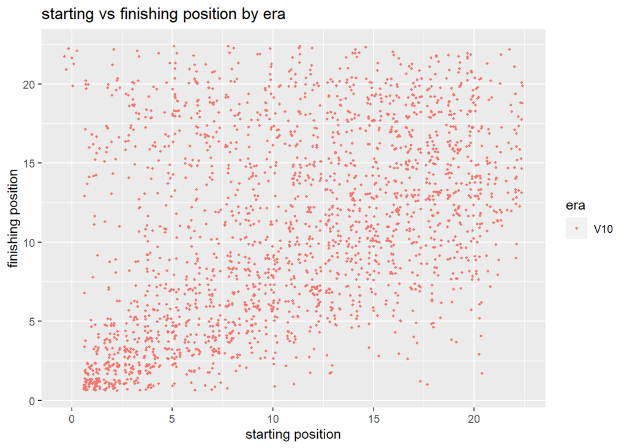

```r
V10plot = F1DataFrame %>% filter(F1DataFrame$era == "V10") %>% ggplot(aes(x = grid, y = positionOrder, colour = era)) +
  geom_point(position = "jitter", size = .8) +
  labs(title="starting vs finishing position by era",
     y="finishing position",
     x="starting position")

V8plot = F1DataFrame %>% filter(F1DataFrame$era == "90 degrees V8") %>% ggplot(aes(x = grid, y = positionOrder, colour = era)) +
  geom_point(position = "jitter", size = .8) +
  labs(title="starting vs finishing position by era",
     y="finishing position",
     x="starting position")

V8MGUsplot = F1DataFrame %>% filter(F1DataFrame$era == "90 degrees V6 + MGUs") %>% ggplot(aes(x = grid, y = positionOrder, colour = era)) +
  geom_point(position = "jitter", size = .8) +
  labs(title="starting vs finishing position by era",
     y="finishing position",
     x="starting position")

V10plot
```

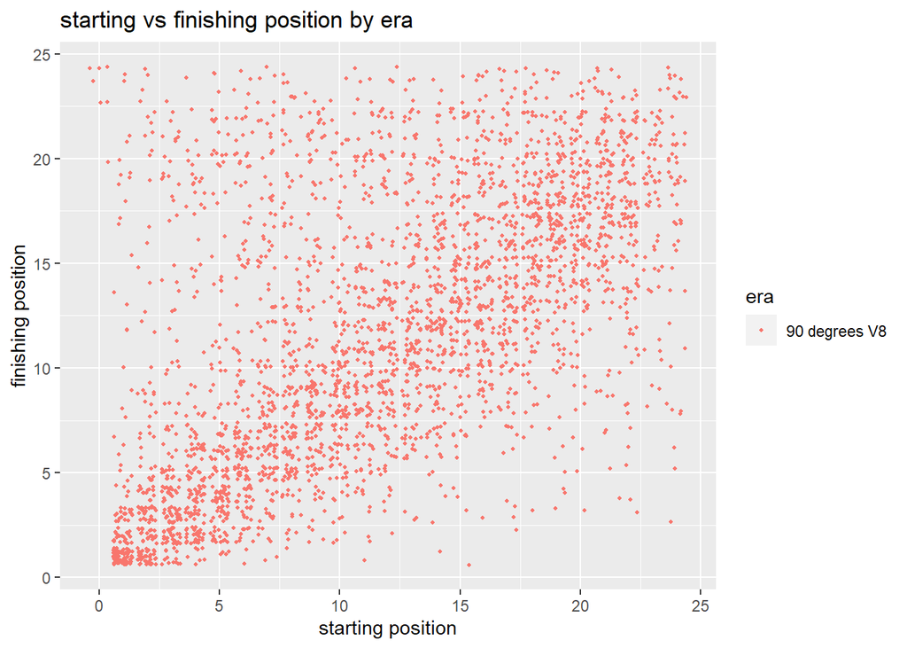

```r
V8plot
```

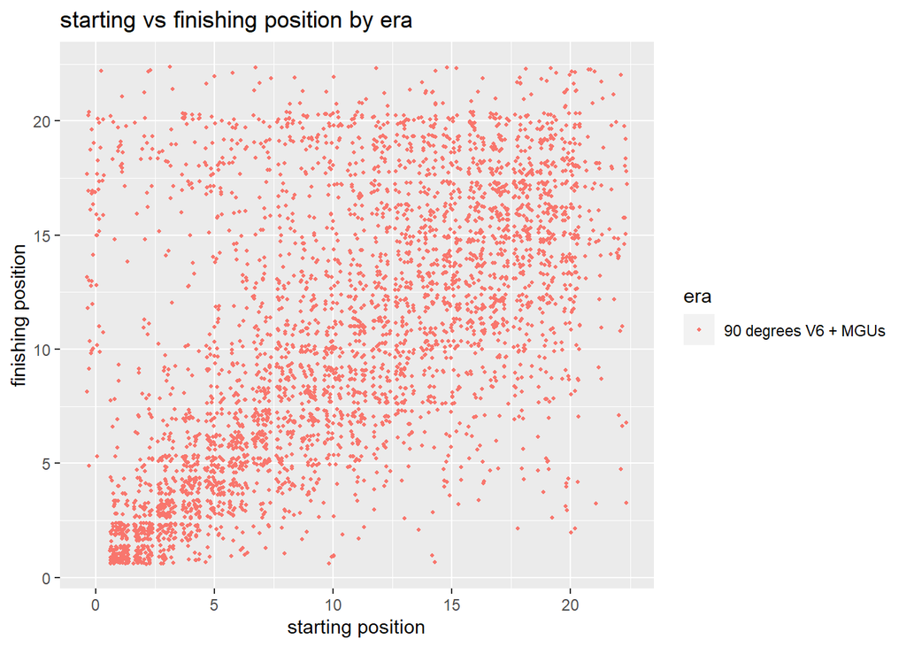

```r
V8MGUsplot
```

# 9 - Model 4 (KNN)

```r
set.seed(1234)
fitControl<-trainControl(method="repeatedcv",number=10,repeats=1)
knn.fit<-train(positionOrder~.,
               data=modelDataframe,
               method="knn",
               trControl=fitControl,
               tuneGrid=expand.grid(k=c(1:10,20,30))
               )
knn.fit
```

```
## k-Nearest Neighbors
##
## 14030 samples
##     4 predictor
##
## No pre-processing
## Resampling: Cross-Validated (10 fold, repeated 1 times)
## Summary of sample sizes: 12626, 12629, 12627, 12626, 12627, 12627, ...
## Resampling results across tuning parameters:
##
##   k   RMSE      Rsquared   MAE
##    1  5.895825  0.3962190  4.631315
##    2  5.738827  0.4196324  4.542079
##    3  5.666648  0.4309476  4.496665
##    4  5.614551  0.4395024  4.466336
##    5  5.583519  0.4447475  4.447944
##    6  5.566017  0.4475374  4.441407
##    7  5.561753  0.4481718  4.440443
##    8  5.551744  0.4499118  4.433137
##    9  5.543840  0.4512980  4.431609
##   10  5.538499  0.4521379  4.431004
##   20  5.519373  0.4552330  4.429668
##   30  5.528506  0.4537695  4.440500
##
## RMSE was used to select the optimal model using the smallest value.
## The final value used for the model was k = 20.
```

# THANK YOU!